# Assignment 6 Text Mining

**Title**: Exploring Joyful Language in Jane Austen’s *Emma* using Tidytext

### **Instructions**

Complete the following exercises using the appropriate packages in R. Ensure that your solutions are optimized and use functional programming principles where applicable.

1. Load the necessary libraries.
2. Answer each question in separate R code chunks.
3. Provide detailed explanations for your approach.
4. Submit the rendered HTML file.

#### **Objective**:

Use the **`tidytext`** package and three different **sentiment lexicons** (`nrc`, `afinn`, `bing`) to explore **positive/joyful words** in *Emma* by Jane Austen. You will tokenize the text, apply sentiment filters, visualize frequent sentiment words using `ggplot2`, and create a word cloud.

### **Tasks**:

1. **Data Preparation**
   - Load the `austen_books()` dataset from the **`janeaustenr`** package.

   ```r
   books <- austen_books()
   head(books)
   ```

   ```
   # A tibble: 6 × 2
     text                    book
     <chr>                   <fct>
   1 "SENSE AND SENSIBILITY" Sense & Sensibility
   2 ""                      Sense & Sensibility
   3 "by Jane Austen"        Sense & Sensibility
   4 ""                      Sense & Sensibility
   5 "(1811)"                Sense & Sensibility
   6 ""                      Sense & Sensibility
   ```

   - Group by book and detect chapter boundaries using regex.

   ```r
   library(stringr)
   original_books <- austen_books() |>
     group_by(book)
   head(original_books)
   ```

   ```
   # A tibble: 6 × 2
   # Groups:   book [1]
     text                    book
     <chr>                   <fct>
   1 "SENSE AND SENSIBILITY" Sense & Sensibility
   2 ""                      Sense & Sensibility
   3 "by Jane Austen"        Sense & Sensibility
   4 ""                      Sense & Sensibility
   5 "(1811)"                Sense & Sensibility
   6 ""                      Sense & Sensibility
   ```

   - Create `linenumber` and `chapter` columns.

   ```r
   grouped_books <- austen_books()|>
     mutate(
       line_number = row_number(),
       chapter = cumsum(str_detect(text, regex("^chapter [\\divxlc]",
                                               ignore_case = TRUE)))
     ) |>
   ungroup()
   ```

   ```r
   tidy_books <- original_books |>
     unnest_tokens(word, text)
   head(tidy_books)
   ```

   ```
   # A tibble: 6 × 2
   # Groups:   book [1]
     book                word
     <fct>               <chr>
   1 Sense & Sensibility sense
   2 Sense & Sensibility and
   3 Sense & Sensibility sensibility
   4 Sense & Sensibility by
   5 Sense & Sensibility jane
   6 Sense & Sensibility austen
   ```

   - *What:* Used `unnest_tokens(word, text)` to split each line into one word per row.
   - *Why:* The tidy format (one token per row) lets you use `dplyr` verbs like `join` and `count`. It also lowercases and strips punctuation, so “Emma,” and “emma” count as the same word.
3. **Sentiment Analysis**
   - Filter joy/positive words from **each** of the three sentiment lexicons:
     - `nrc` (joy)
     - `afinn` (positive scores ≥ 1)
     - `bing` (positive)

   ```r
   library(textdata)
   library(dplyr)
   nrc_joy <- get_sentiments("nrc") |>
     filter(sentiment == "joy")

   afinn_positive <- get_sentiments("afinn") |>
     filter(value >= 1)

   bing_positive <- get_sentiments("bing") |>
     filter(sentiment == "positive")

   nrow(nrc_joy)
   ```

   ```
   [1] 687
   ```

   ```r
   nrow(afinn_positive)
   ```

   ```
   [1] 878
   ```

   ```r
   nrow(bing_positive)
   ```

   ```
   [1] 2005
   ```

   - *What:* Filtered joy words from `nrc`, positive scores (`value >= 1`) from `afinn`, and positive words from `bing`.
   - *Why:* Each lexicon is structured differently: NRC has emotion categories, AFINN has numeric scores, and Bing has binary labels. So each needs a different filter to define “positive.” You can also note that this means the three lists differ in size and coverage.
   - **Join each with *Emma*’s text and:**
     - Count word frequency.
     - Filter for frequently occurring words (`n > 50`).
     - Visualize using a **bar chart** (`ggplot2`) and a **word cloud** (`wordcloud`).

   ```r
   library(wordcloud)
   emma <- tidy_books |>
     filter(book == "Emma")

   emma_nrc <- emma |>
     inner_join(nrc_joy, by = "word") |>
     count(word, sort = TRUE) |>
     filter(n > 50)

   emma_afinn <- emma |>
     inner_join(afinn_positive, by = "word") |>
     count(word, sort = TRUE) |>
     filter(n > 50)

   emma_bing <- emma |>
     inner_join(bing_positive, by = "word") |>
     count(word, sort = TRUE) |>
     filter(n > 50)
   ```

   - *What:* Used `inner_join()` to keep only Emma words found in each lexicon, then `count()` and `filter(n > 50)`.
   - *Why:* An inner join drops words with no sentiment label. The `n > 50` threshold focuses on the words that actually shape the book’s tone rather than rare one-offs.

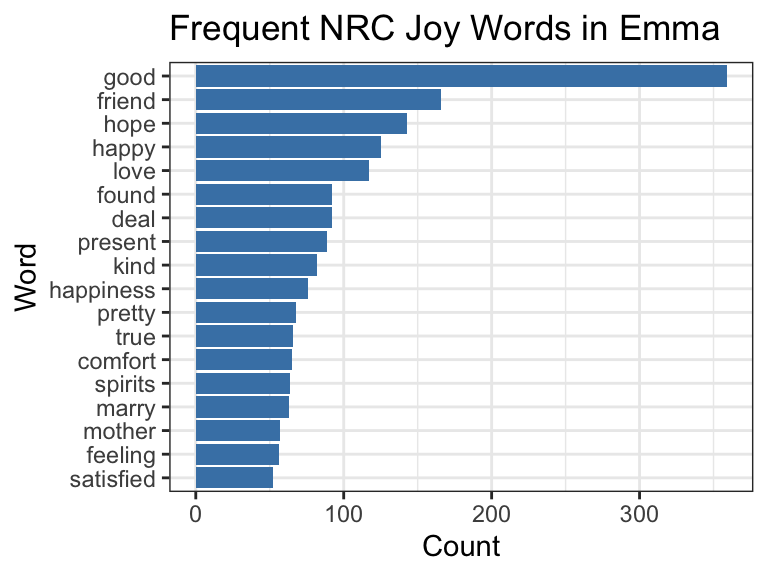

   ```r
   plot_bar <- function(df, title) {
     ggplot(df, aes(x = reorder(word, n), y = n)) +
       geom_col(fill = "steelblue") +
       coord_flip() +
       labs(title = title, x = "Word", y = "Count")
   }

   plot_cloud <- function(df, title) {
     set.seed(123)
     wordcloud(words = df$word, freq = df$n, min.freq = 1,
               random.order = FALSE, colors = brewer.pal(8, "Dark2"))
     title(title)
   }

   plot_bar(emma_nrc, "Frequent NRC Joy Words in Emma")
   ```

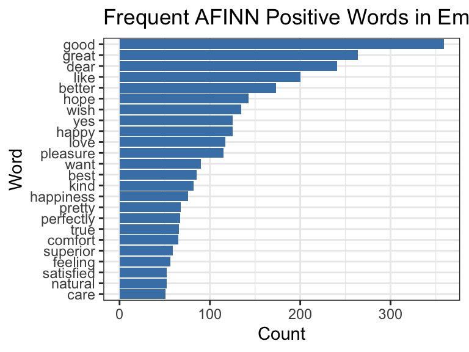

   ```r
   plot_bar(emma_afinn, "Frequent AFINN Positive Words in Emma")
   ```

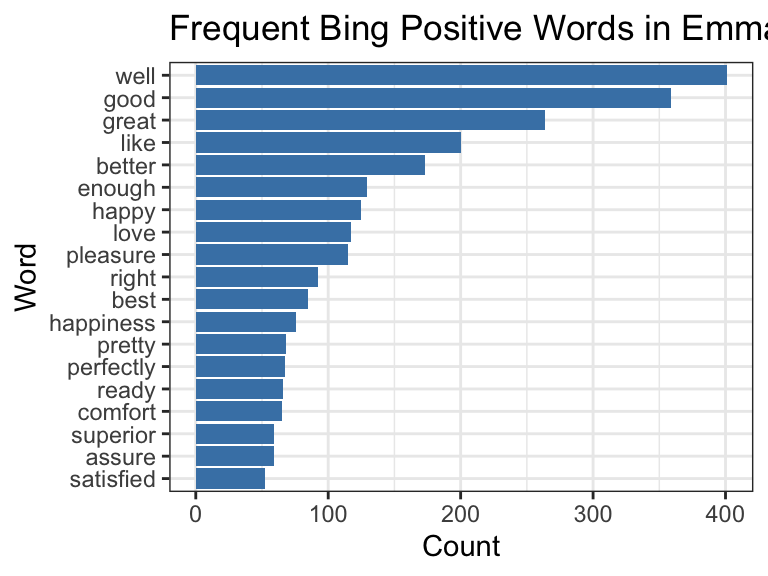

   ```r
   plot_bar(emma_bing, "Frequent Bing Positive Words in Emma")
   ```

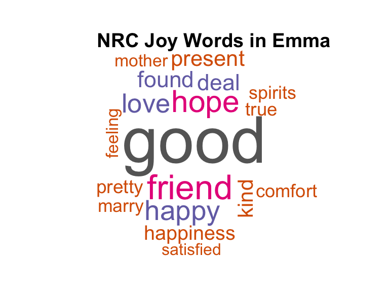

   ```r
   plot_cloud(emma_nrc, "NRC Joy Words in Emma")
   ```

[figure not shown]

   ```r
   plot_cloud(emma_afinn, "AFINN Positive Words in Emma")
   ```

[figure not shown]

   ```r
   plot_cloud(emma_bing, "Bing Positive Words in Emma")
   ```

   - *What:* A bar chart and word cloud per lexicon.
   - *Why:* Bar charts show exact counts and make ranking easy. Word clouds give a quick visual impression of relative frequency, but are less precise. Using both gives precision and overview.
4. **Push to GitHub**
   - Push your complete rendred qmd (`.html` file) to a **GitHub repository**.
   - Your file should include:
     - Data wrangling
     - Sentiment filtering and joins
     - Visualization code
   - You must include **at least 5 meaningful commits** to document your workflow.

## **Rubric 100 Points**

| Category | Points |
| --- | --- |
| Step 1: Data wrangling (linenumber, chapter) | 10 |
| Step 2: Tokenization | 10 |
| Step 3a: NRC sentiment analysis + plots | 10 |
| Step 3b: AFINN sentiment analysis + plots | 10 |
| Step 3c: BING sentiment analysis + plots | 10 |
| Code readability, structure, and comments | 10 |
| Word cloud for each lexicon | 20 |
| GitHub submission |  |
| Commit history (at least 5 meaningful commits) | 20 |
| **Total** | **100** |

Good Luck!